# RENDU-PROJET CLASSIFICATION

Bernice AGOSSOUVO

17/06/2021

## Chargement des bibliothèques utiles dans le cadre de ce projet

```r
## Chargement des biblioteques
library(readr)
```

```r
library(ggplot2)
library(readxl)
library(prettyR)
library(questionr)
library(randomForest)
```

## 1) Chargement du jeu de données d’apprentissage

```r
algue = read.table(file = "Ex4.dataTrain.txt",header = TRUE)
```

### Description statistique des variables

```r
summary(algue)
```

```
##     season              size              speed                mxPH
##  Length:134         Length:134         Length:134         Min.   :7.090
##  Class :character   Class :character   Class :character   1st Qu.:7.800
##  Mode  :character   Mode  :character   Mode  :character   Median :8.100
##                                                           Mean   :8.087
##                                                           3rd Qu.:8.400
##                                                           Max.   :9.101
##       mnO2              Cl              NO3              NH4
##  Min.   : 1.500   Min.   :  0.80   Min.   : 0.050   Min.   :    5.80
##  1st Qu.: 7.900   1st Qu.: 11.94   1st Qu.: 1.324   1st Qu.:   51.19
##  Median : 9.700   Median : 35.95   Median : 2.921   Median :  119.29
##  Mean   : 9.005   Mean   : 47.03   Mean   : 3.392   Mean   :  567.26
##  3rd Qu.:10.660   3rd Qu.: 58.88   3rd Qu.: 4.550   3rd Qu.:  238.25
##  Max.   :13.400   Max.   :391.50   Max.   :45.650   Max.   :24064.00
##       oPO4              Chla              freq
##  Min.   :  1.333   Min.   :  0.200   Min.   :0.0000
##  1st Qu.: 18.778   1st Qu.:  2.000   1st Qu.:0.0000
##  Median : 48.312   Median :  5.216   Median :0.0000
##  Mean   : 75.653   Mean   : 14.108   Mean   :0.4925
##  3rd Qu.:102.356   3rd Qu.: 18.120   3rd Qu.:1.0000
##  Max.   :564.600   Max.   :110.456   Max.   :1.0000
```

```r
describe(algue)
```

```
## [134 obs. x 11 variables] tbl_df tbl data.frame
##
## $season:
## character: "spring" "summer" "autumn" "winter" "winter" "spring" "winter" "spring" "winter" "spring" ...
## NAs: 0 (0%) - 4 unique values
##
## $size:
## character: "medium" "small" "small" "small" "large" "small" "small" "small" "medium" "medium" ...
## NAs: 0 (0%) - 3 unique values
##
## $speed:
## character: "high" "high" "high" "high" "medium" "high" "medium" "medium" "medium" "medium" ...
## NAs: 0 (0%) - 3 unique values
##
## $mxPH:
## numeric: 8.30021704253787 7.72027480969345 7.400455494822 7.89931910517858 8.49985914533632 8.30051972512947 8.00080382501101 8.34990389201557 8.50097497477103 8.00028752578609 ...
## min: 7.08971779259574 - max: 9.10098548735119 - NAs: 0 (0%) - 134 unique values
##
## $mnO2:
## numeric: 7.7 11.8 12.5 11 10.5 12.5 9.8 8 8.6 3.3 ...
## min: 1.5 - max: 13.4 - NAs: 0 (0%) - 73 unique values
##
## $Cl:
## numeric: 10.078 6.3 13 6.167 2.75 87 60.8 57.75 125.6 26.76 ...
## min: 0.8 - max: 391.5 - NAs: 0 (0%) - 130 unique values
##
## $NO3:
## numeric: 1.212 1.47 3.33 1.172 0.758 4.87 6.238 1.288 3.778 0.658 ...
## min: 0.05 - max: 45.65 - NAs: 0 (0%) - 132 unique values
##
## $NH4:
## numeric: 103.333 8 60 18.333 10.5 22.5 578 370 124.167 165 ...
## min: 5.8 - max: 24064 - NAs: 0 (0%) - 131 unique values
##
## $oPO4:
## numeric: 48.667 16 72 7.75 4 27 105 428.75 197.83299 37.375 ...
## min: 1.333 - max: 564.59998 - NAs: 0 (0%) - 124 unique values
##
## $Chla:
## numeric: 2 0.5 4.9 0.5 4 3.3 50 1.3 40 3 ...
## min: 0.2 - max: 110.456 - NAs: 0 (0%) - 100 unique values
##
## $freq:
## integer: 0 0 1 0 0 0 1 1 1 0 ...
## min: 0 - max: 1 - NAs: 0 (0%) - 2 unique values
```

```r
attach(algue)
```

Nous avons 11 variables dont 03 variables qualitatives ( season, size et speed) à respectivement 04, 03 et 03 modalités et 08 variables quantitatives dont la variable freq

### Transformation de la variable freq en facteur

```r
algue$freq <- as.factor(algue$freq)
summary(algue)
```

```
##     season              size              speed                mxPH
##  Length:134         Length:134         Length:134         Min.   :7.090
##  Class :character   Class :character   Class :character   1st Qu.:7.800
##  Mode  :character   Mode  :character   Mode  :character   Median :8.100
##                                                           Mean   :8.087
##                                                           3rd Qu.:8.400
##                                                           Max.   :9.101
##       mnO2              Cl              NO3              NH4
##  Min.   : 1.500   Min.   :  0.80   Min.   : 0.050   Min.   :    5.80
##  1st Qu.: 7.900   1st Qu.: 11.94   1st Qu.: 1.324   1st Qu.:   51.19
##  Median : 9.700   Median : 35.95   Median : 2.921   Median :  119.29
##  Mean   : 9.005   Mean   : 47.03   Mean   : 3.392   Mean   :  567.26
##  3rd Qu.:10.660   3rd Qu.: 58.88   3rd Qu.: 4.550   3rd Qu.:  238.25
##  Max.   :13.400   Max.   :391.50   Max.   :45.650   Max.   :24064.00
##       oPO4              Chla         freq
##  Min.   :  1.333   Min.   :  0.200   0:68
##  1st Qu.: 18.778   1st Qu.:  2.000   1:66
##  Median : 48.312   Median :  5.216
##  Mean   : 75.653   Mean   : 14.108
##  3rd Qu.:102.356   3rd Qu.: 18.120
##  Max.   :564.600   Max.   :110.456
```

## 2) Chargement du package RandomForest

```r
library(randomForest)
help("randomForest")
```

```
## starting httpd help server ... done
```

randomForest met en œuvre l’algorithme de forêt aléatoire de Breiman (basé sur le code Fortran original de Breiman et Cutler) pour la classification et la régression. Il peut également être utilisé en mode non supervisé pour évaluer les proximités entre les points de données. les codes suivants montrent l’utilisation de ce package

## 3) Construire l’objet fit à l’aide de la commande randomForest en spécifiant importance = T

```r
fit.rf <- randomForest(freq ~ ., data = algue, importance =TRUE)
print(fit.rf) # affiche l'objet crée
```

```
##
## Call:
##  randomForest(formula = freq ~ ., data = algue, importance = TRUE)
##                Type of random forest: classification
##                      Number of trees: 500
## No. of variables tried at each split: 3
##
##         OOB estimate of  error rate: 10.45%
## Confusion matrix:
##    0  1 class.error
## 0 60  8  0.11764706
## 1  6 60  0.09090909
```

### Explication de la sortie

On voit d’abord un rappel de la formule utilisée

Après s’ensuit le type of random forest : Classification (puisque notre variable à expliquer est de type qualitative)

On apprend après que la forêt est composée de 500 arbres, qu’à chaque noeud l’algorithme fait un essai sur 3 variables, le taux d’erreur (out of bag error OOB qui est une mesure de l’erreur de prédiction) est donné

en effet “Chaque arbre de la forêt est construit sur une fraction (“in bag”) des données (c’est la fraction qui sert à l’entraînement de l’algorithme. Alors pour chacun des individus de la fraction restante (“out of bag”) l’arbre peut prédire une classe.” Le but du jeu est d’obtenir l’OOB le plus petit possible

et pour finir, nous avons **la matrice de confusion**

## 4) Graphique montrant comment réduit l’OOB en fonction du nombre d’arbres générés.

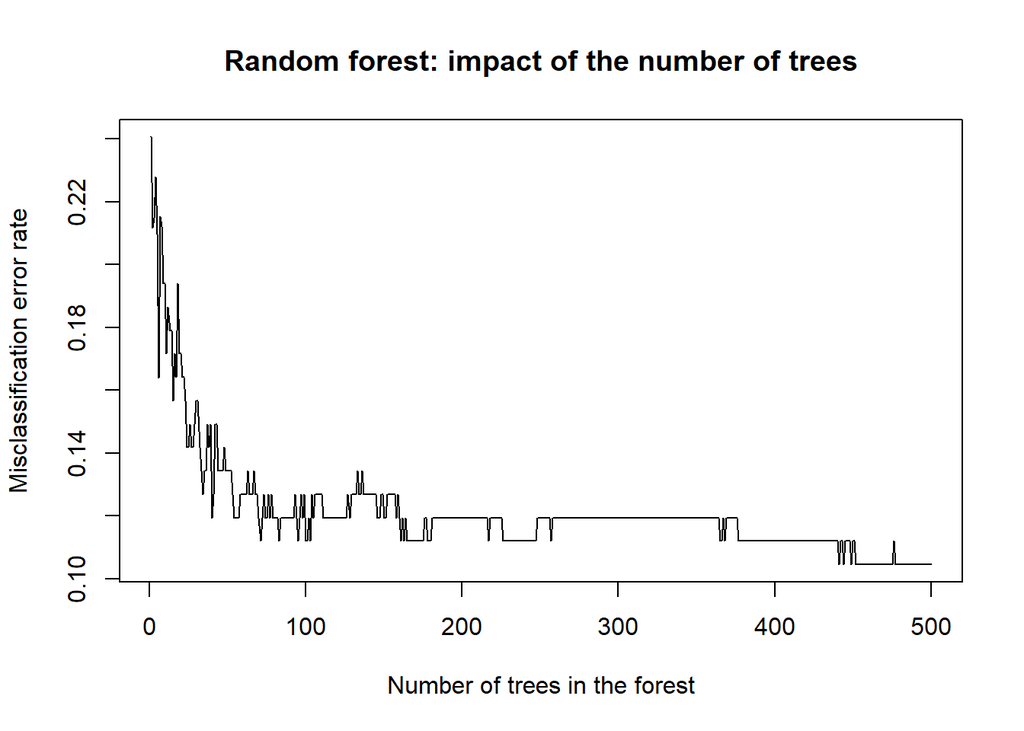

```r
plot(fit.rf$err.rate[,1],
     type = "l",
     main = "Random forest: impact of the number of trees",
     xlab = "Number of trees in the forest",
     ylab = "Misclassification error rate")
```

On cherche le nombre d’arbres qui stabilise l’OOB au minimum. On va voir ce que cela donnerait avec 2000 arbres

```r
set.seed(123)
fit <- randomForest(freq ~., data = algue, ntree = 2000)
print(fit)
```

```
##
## Call:
##  randomForest(formula = freq ~ ., data = algue, ntree = 2000)
##                Type of random forest: classification
##                      Number of trees: 2000
## No. of variables tried at each split: 3
##
##         OOB estimate of  error rate: 11.19%
## Confusion matrix:
##    0  1 class.error
## 0 59  9  0.13235294
## 1  6 60  0.09090909
```

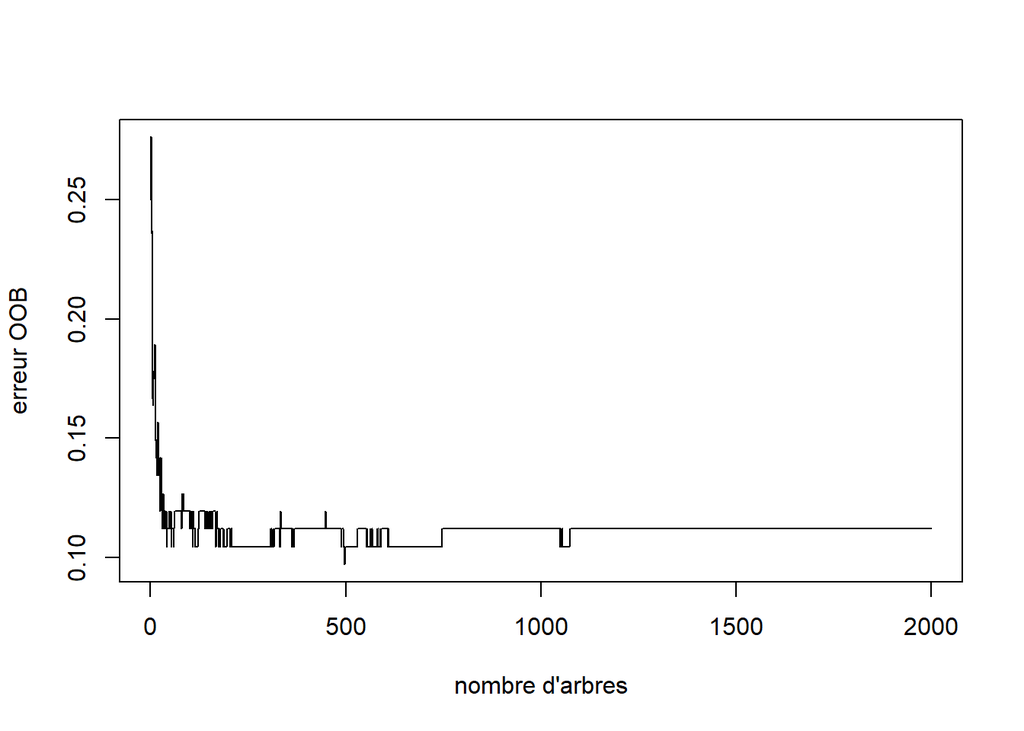

```r
plot(fit$err.rate[, 1], type = "l", xlab = "nombre d'arbres", ylab = "erreur OOB")
```

## 5)

```r
fit.rf$oob.times
```

```
##   [1] 192 174 156 168 183 193 176 201 186 198 182 156 170 163 196 186 197 179
##  [19] 174 177 182 185 204 177 181 184 183 192 174 163 185 180 183 202 178 186
##  [37] 175 176 196 164 185 199 195 193 172 200 184 184 200 201 200 164 184 179
##  [55] 177 168 195 193 197 183 185 182 205 167 165 195 186 182 179 188 191 163
##  [73] 189 184 196 190 180 181 194 186 185 171 173 197 182 182 160 185 188 179
##  [91] 194 181 178 191 197 160 178 180 175 166 201 187 194 169 190 166 217 191
## [109] 178 198 179 176 173 184 181 190 197 180 184 175 199 171 182 180 183 187
## [127] 204 163 179 183 181 171 186 187
```

la fonction **fit.rf$oob.times* renvoie le nombre de fois où chaque individu est “out of bag”

### Histogramme des OOB

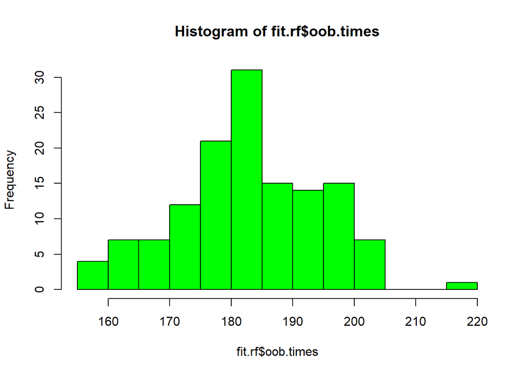

```r
hist(fit.rf$oob.times,col = "green")
```

et on peut aussi s’intéresser à la proportion de votes que chaque classe a recueilli avec **fit.rf$votes**

```r
fit.rf$votes[1:10,]
```

```
##              0         1
## 131 0.92187500 0.0781250
## 14  1.00000000 0.0000000
## 31  0.84615385 0.1538462
## 53  1.00000000 0.0000000
## 182 1.00000000 0.0000000
## 46  0.85492228 0.1450777
## 1   0.03977273 0.9602273
## 2   0.17910448 0.8208955
## 90  0.05376344 0.9462366
## 79  0.54545455 0.4545455
```

## 6) Analyser l’importance des variables explicatives

Quelles sont les variables qui figurent dans notre modèle et discriminant le mieux la variable à expliquer ? On peut faire un premier graphique qui va nous présenter l’importance des variables explicatives pour distinguer les cours d’eaux dont le seuil de prolifération d’algues toxiques nécéssitant une cation est atteint.

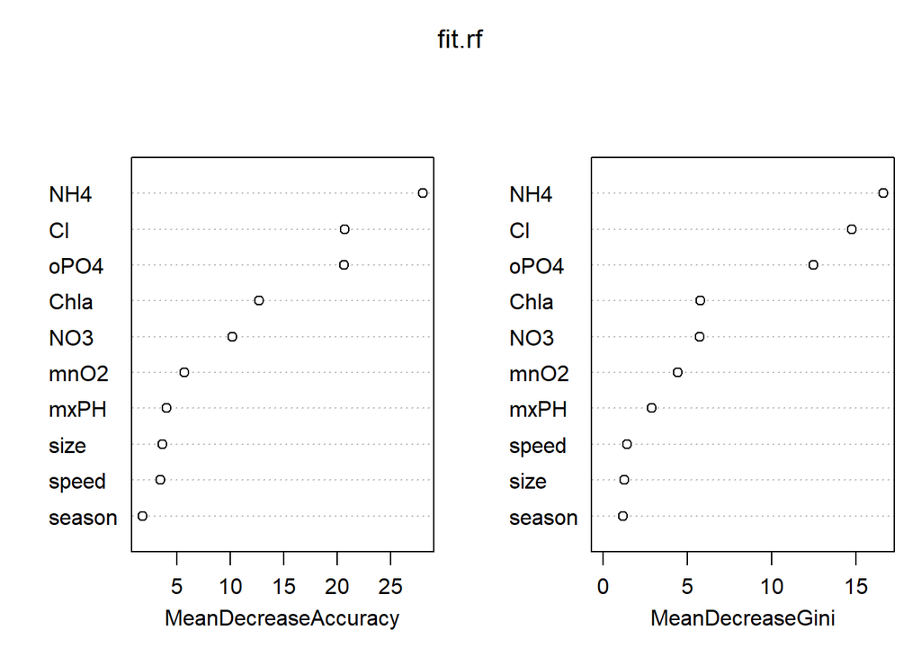

```r
varImpPlot(fit.rf)
```

On trouve les mêmes informations dans un tableau avec les commandes suivantes :

```r
fit.rf$importance[order(fit.rf$importance[, 1], decreasing = TRUE), ]
```

```
##                   0           1 MeanDecreaseAccuracy MeanDecreaseGini
## NH4    0.0990425429 0.106328212          0.101018421        16.600840
## oPO4   0.0814944133 0.065200139          0.072799583        12.483842
## Cl     0.0420881945 0.100885060          0.070374151        14.746170
## Chla   0.0277547875 0.026350371          0.026573047         5.779703
## NO3    0.0194277483 0.020669232          0.019632685         5.712455
## mnO2   0.0117256084 0.005506289          0.008437198         4.443341
## size   0.0036713696 0.003422268          0.003489474         1.252059
## speed  0.0029667135 0.003735623          0.003267312         1.408166
## mxPH   0.0026037225 0.008492070          0.005394621         2.905620
## season 0.0006562193 0.002509078          0.001703228         1.184789
```

Dans le modèle calculé, les trois variables ayant une forte importance sont NH4,oPO4 et Cl

On peut visualiser graphiquement le comportement de chaque variable avec la variable freq

### Variable NH4

```r
split.screen(1:2)
```

```
## [1] 1 2
```

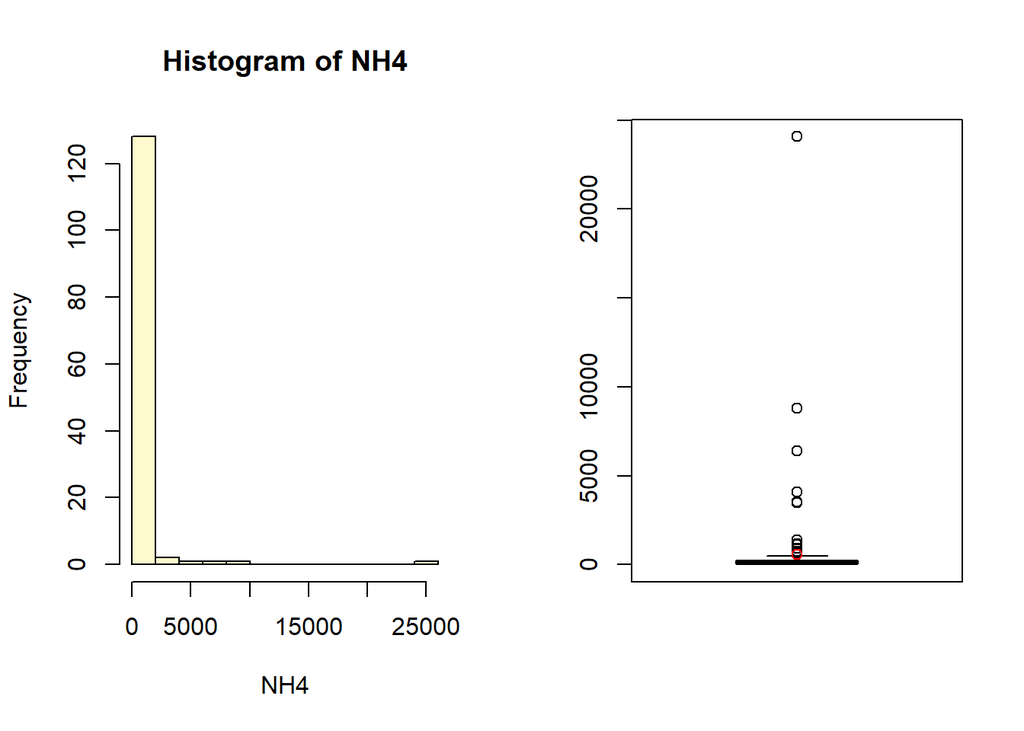

```r
screen(1) ; hist(NH4, col="#FFFACD")
screen(2) ; boxplot(NH4)
points(mean(NH4),col="red")
```

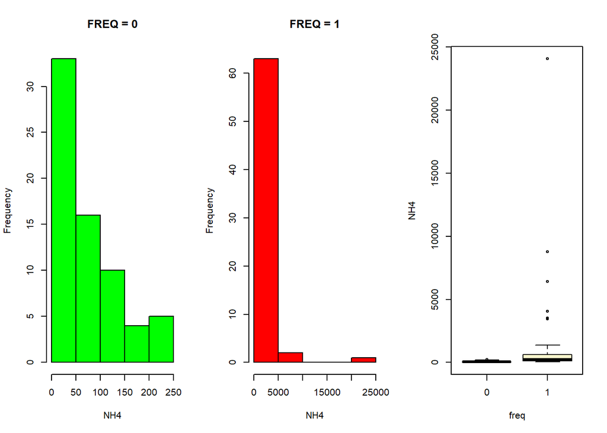

```r
close.screen(all = TRUE)
par(mfrow = c(1, 3))
hist(algue$NH4[algue$freq == 0], main = "FREQ = 0", xlab ="NH4", col = "green")
hist(algue$NH4[algue$freq == 1], main = "FREQ = 1",xlab ="NH4", col = "red")
boxplot(NH4~ freq,varwidth = FALSE, col="#FFFACD")
```

On remarque ainsi que le **NH4** est **très present** dans les cours d’eau à forte prolifération des algues toxiques avec un maximum de 25000 alors que pour les cours d’eau dont la freq est 0, le maximum est à 250. la même remarque est faite sur les variables Cl et opo4. ci dessous la representation graphique

### Variable Cl

```r
split.screen(1:2)
```

```
## [1] 1 2
```

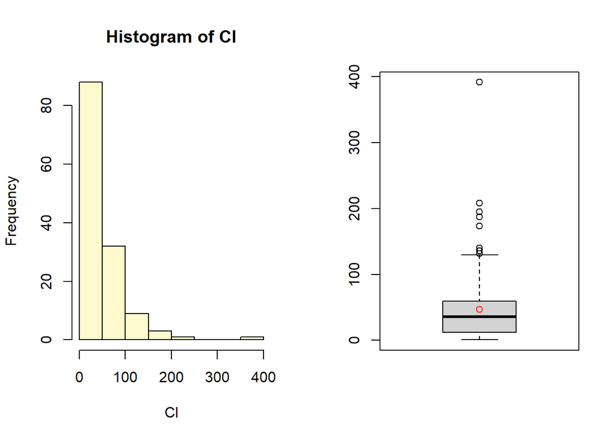

```r
screen(1) ; hist(Cl, col="#FFFACD")
screen(2) ; boxplot(Cl)
points(mean(Cl),col="red")
```

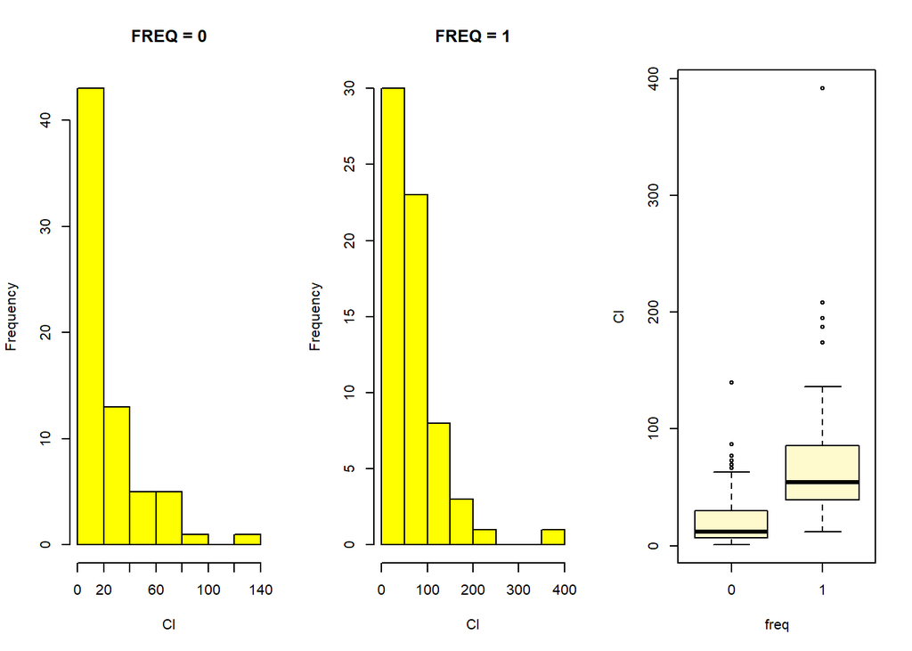

```r
close.screen(all = TRUE)
par(mfrow = c(1, 3))
hist(algue$Cl[algue$freq == 0], main = "FREQ = 0", xlab ="Cl", col = "yellow")
hist(algue$Cl[algue$freq == 1], main = "FREQ = 1",xlab ="Cl", col = "yellow")
boxplot(Cl~ freq,varwidth = FALSE, col="#FFFACD")
```

Il n’y a pas de chevauchement au niveau des boites à moustaches. la moyenne de cl dans les cours d’eau quand freq est 0 ou freq est égale à 1 sont très differentes. Cela s’explique par le fait qu’il est aussi importante dans la modélisation

### Variable oPO4

```r
split.screen(1:2)
```

```
## [1] 1 2
```

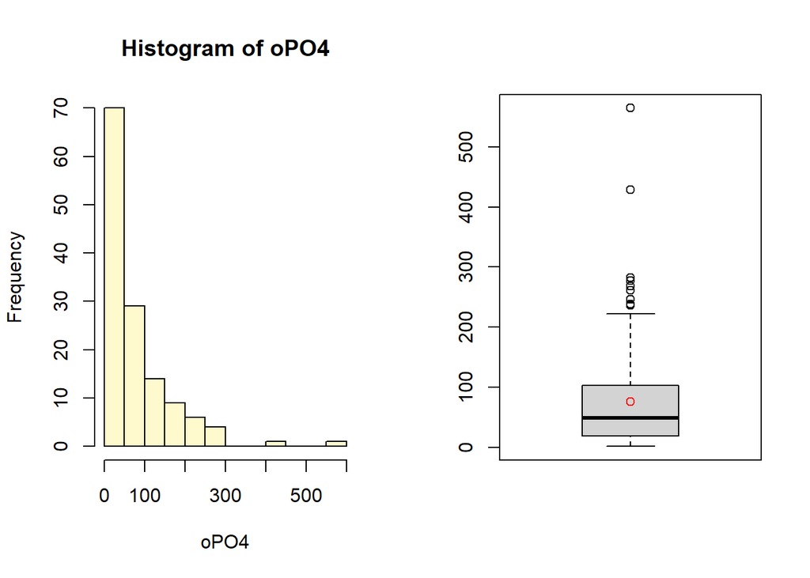

```r
screen(1) ; hist(oPO4, col="#FFFACD")
screen(2) ; boxplot(oPO4)
points(mean(oPO4),col="red")
```

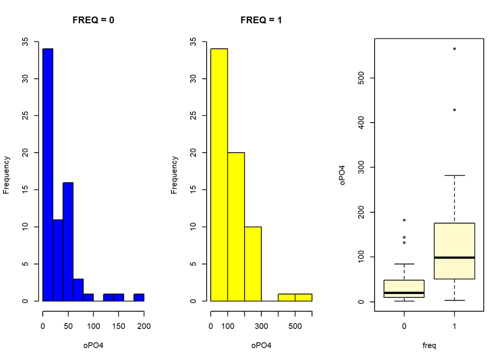

```r
close.screen(all = TRUE)
par(mfrow = c(1, 3))
hist(algue$oPO4[algue$freq == 0], main = "FREQ = 0", xlab ="oPO4", col = "blue")
hist(algue$oPO4[algue$freq == 1], main = "FREQ = 1",xlab ="oPO4", col = "yellow")
boxplot(oPO4~ freq,varwidth = FALSE, col="#FFFACD")
```

Même remarque que précedemment

## 8) Prédire pour le jeu de donnée test

```r
test = read.table(file = "Ex4.dataTest.txt",header = TRUE)
```

```r
test$predicted <- predict(fit.rf, test)
table(test$predicted)
```

```
##
##  0  1
## 26 24
```

## 9)Changer la valeur de mtry pour construire un modèle Bagging et faites une prédiction pour le jeu de donnée test.

```r
library(ipred)
bag <- bagging(freq ~., data=algue, coob=TRUE)
print(bag)
```

```
##
## Bagging classification trees with 25 bootstrap replications
##
## Call: bagging.data.frame(formula = freq ~ ., data = algue, coob = TRUE)
##
## Out-of-bag estimate of misclassification error:  0.1716
```

```r
test$predicted2 <- predict(bag, test)
```

## 10) Proposer une procédure afin de sélectionner le meilleur mtry au sens de la minimisation du taux d’erreur OOB.

```r
v.err <-  NULL
v.mtry <- c(1, 2,3, 4, 5, 6, 7, 8,9)
for(i in v.mtry){
    set.seed(123)
    fit.rf <- randomForest(freq~., data = algue, ntree= 2000, mtry=i)
    v.err <- c(v.err, fit.rf$err.rate[2000,1])
}
```

```r
v.err
```

```
##       OOB       OOB       OOB       OOB       OOB       OOB       OOB       OOB
## 0.1268657 0.1044776 0.1119403 0.1268657 0.1194030 0.1268657 0.1268657 0.1343284
##       OOB
## 0.1268657
```

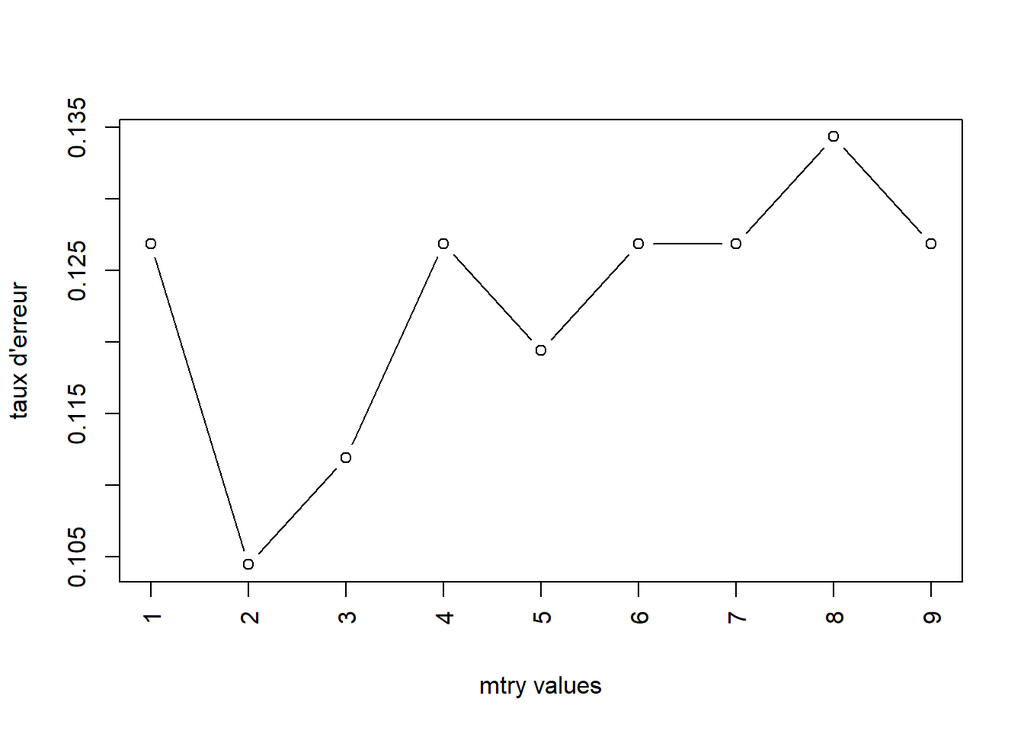

```r
plot(v.mtry, v.err, type ="b", xlab="mtry values", ylab="taux d'erreur", xaxt="n")
axis(1, at=v.mtry, labels=v.mtry, las=2)
```

```r
fit.rf <- randomForest(freq ~ ., data = algue,mtry = 4, ntree =2000, importance =TRUE)
print(fit.rf)
```

```
##
## Call:
##  randomForest(formula = freq ~ ., data = algue, mtry = 4, ntree = 2000,      importance = TRUE)
##                Type of random forest: classification
##                      Number of trees: 2000
## No. of variables tried at each split: 4
##
##         OOB estimate of  error rate: 12.69%
## Confusion matrix:
##    0  1 class.error
## 0 57 11  0.16176471
## 1  6 60  0.09090909
```